# 계산영상 시스템 HW2

## Eulerian Video Magnification

```python
import numpy as np
import cv2
import skimage
from skimage import color
import matplotlib.pyplot as plt
from scipy.signal import butter, lfilter, freqz
```

### INITIALS AND COLOR TRANSFORMATION

Load the video file

Extract its frames, and convert them to double-precision in the range [0, 1]

Convert each of the frames to the YIQ color space

```python
cap = cv2.VideoCapture('./data/face.mp4')

frame_n = int(cap.get(cv2.CAP_PROP_FRAME_COUNT))
width, height = int(cap.get(cv2.CAP_PROP_FRAME_WIDTH)),int(cap.get(cv2.CAP_PROP_FRAME_HEIGHT))

images=np.zeros((frame_n,height,width,3),dtype='double')
i = 0
while cap.isOpened():
    ret, frame=cap.read() # BGR
    if ret is True:
        frame = cv2.cvtColor(frame, cv2.COLOR_BGR2RGB)
        images[i]=frame
        i+=1
    else:
        break
images.shape
```

```
(301, 592, 528, 3)
```

```python
cap = cv2.VideoCapture('./data/baby2.mp4')

frame_n = int(cap.get(cv2.CAP_PROP_FRAME_COUNT))
width, height = int(cap.get(cv2.CAP_PROP_FRAME_WIDTH)),int(cap.get(cv2.CAP_PROP_FRAME_HEIGHT))

images=np.zeros((frame_n,height,width,3),dtype='double')
i = 0
while cap.isOpened():
    ret, frame=cap.read() # BGR
    if ret is True:
        frame = cv2.cvtColor(frame, cv2.COLOR_BGR2RGB)
        images[i]=frame
        i+=1
    else:
        break
images.shape
```

```
(900, 352, 640, 3)
```

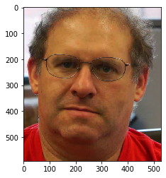

```python
plt.imshow(images[0]/255)
```

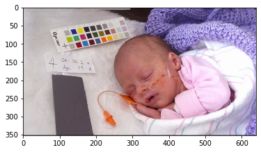

```python
plt.imshow(images[0]/255)
```

```python
for i in range(images.shape[0]):
    images[i] = color.rgb2yiq(images[i])
```

```
Clipping input data to the valid range for imshow with RGB data ([0..1] for floats or [0..255] for integers).
```

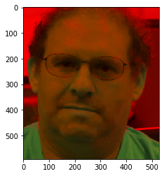

```python
plt.imshow(images[0]/255)
```

```
Clipping input data to the valid range for imshow with RGB data ([0..1] for floats or [0..255] for integers).
```

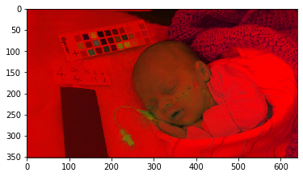

```python
plt.imshow(images[0]/255)
```

### LAPLACIAN PYRAMID

Construct a Laplacian pyramid for every single frame in the video sequence

두개의 이미지가 최소 사이즈가 되는 10 level들의 이미지 피라미드를 만듬

먼저 가우시안 피라이미를 만든 다음에 라플라시안 피라이드를 생성

오리지널 이미지에서 가우시안 필터 + 이미지 사이즈 감소를 반복하여 가우시안 피라이드를 만들고

한 레벨 높은 가우시안 이미지에서 본 레벨 이미지를 빼서 라플라시안 피라미드를 생성

라플라시안 피라미드는 level 9

```python
g_pyramid = [] # make empty pyramid
l_pyramid = []
img = images[0]
for i in range(10):
    g_pyramid.append(np.zeros((images.shape[0], img.shape[0], img.shape[1], img.shape[2])))
    l_pyramid.append(np.zeros((images.shape[0], img.shape[0], img.shape[1], img.shape[2])))
    img = cv2.pyrDown(img)

for i in range(images.shape[0]): # make Gaussian pyramid
    img = images[i]
    for j in range(10):
        g_pyramid[j][i] = img
        img = cv2.pyrDown(img)

for i in range(images.shape[0]): # make Laplacian pyramid
    for j in range(9):
        l_pyramid[j][i] = cv2.subtract(g_pyramid[j][i], cv2.resize(cv2.pyrUp(g_pyramid[j+1][i]), dsize=(g_pyramid[j][i].shape[1], g_pyramid[j][i].shape[0])))
```

```python
levels = 3
```

### TEMPORAL FILTERING

Consider the time series corresponding to the value of a pixel on all spatial levels of the Laplacian pyramid

Convert this time series to the frequency domain using the Fast Fourier Transform

apply a band pass filter to this signal

과제에서 주어진 논문을 통해서 필터와 파라미터를 선정

필터의 경우 논문에 주어진데로 ideal filter를 선택함

```python
def bandpass_filter(data, lowcut, highcut, fs, order=5):
    frequencies = np.fft.fftfreq(data.shape[0], d=1.0/fs)
    mask = np.logical_and(frequencies > lowcut, frequencies < highcut)
    data[~mask] = 0
    return data
```

```python
fftx = np.fft.fft(g_pyramid[levels], axis=0)
ffty = bandpass_filter(fftx.copy(), 0.83, 1, 30, order=1)
filtered_x = np.fft.ifft(ffty, axis=0)
```

```python
fftx = np.fft.fft(g_pyramid[levels], axis=0)
ffty = bandpass_filter(fftx.copy(), 2.33, 2.67, 30, order=1)
filtered_x = np.fft.ifft(ffty, axis=0)
```

### EXTRACTING THE FREQUENCY BAND OF INTEREST

Try to observe a variety of video data in frequency domain and identify the frequency band of interest

Analyzing the histogram of frequency responses can be useful to understand the context of your video

주파수의 히스토그램 대신에 임의의 값을 넣었음 face 영상의 알파값이 200, baby2 영상의 알파값이 400

```python
filtered_x *= 200
```

```python
filtered_x *= 400
```

### IMAGE RECONSTRUCTION

After amplifying the signals, all that is left is to collapse the Laplacian pyramids into a single image per frame.

생성된 라플라시안 피라미드를 통해서 원본 사이즈의 이미즈를 재구축

필터링된 이미지를 가우시안 필터 + 사이즈업 한후 한단계 높은 라플라시안 이미지를 더함

```python
final = np.zeros(images.shape)
for i in range(final.shape[0]): # frames
    tmp = filtered_x[i] # level 10 gaussian
    for j in range(levels-1, -1, -1):
        tmp = cv2.pyrUp(np.abs(tmp), dstsize = (l_pyramid[j][i].shape[1], l_pyramid[j][i].shape[0])) + l_pyramid[j][i]
    final[i] = tmp
```

```
Clipping input data to the valid range for imshow with RGB data ([0..1] for floats or [0..255] for integers).
```

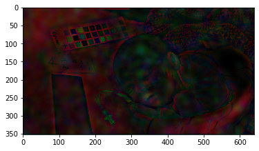

```python
plt.imshow(final[1]/255)
```

```python
final = final + images
```

```python
for i in range(final.shape[0]):
    final[i] = skimage.color.yiq2rgb(final[i])
```

```
Clipping input data to the valid range for imshow with RGB data ([0..1] for floats or [0..255] for integers).
```

[figure not shown]

```python
plt.imshow(final[1]/255)
```

```python
final[final < 0] = 0
final[final > 255] = 255
```

```python
out = cv2.VideoWriter('face_result.avi',cv2.VideoWriter_fourcc(*'DIVX'), 30, (final[0].shape[1], final[0].shape[0]))
for i in range(len(final)):
    tmp = np.uint8(final[i])
    tmp = cv2.cvtColor(tmp, cv2.COLOR_BGR2RGB)
    out.write(tmp)
out.release()
```

```python
out = cv2.VideoWriter('baby2_result.avi',cv2.VideoWriter_fourcc(*'DIVX'), 30, (final[0].shape[1], final[0].shape[0]))
for i in range(len(final)):
    tmp = np.uint8(final[i])
    tmp = cv2.cvtColor(tmp, cv2.COLOR_BGR2RGB)
    out.write(tmp)
out.release()
```